# Statistical Analysis

Rafael Peñaloza

2022-05-19

## Visual Analysis

Getting first the summary of the data, grouped by cell type and surface

```
## # A tibble: 6 × 5
## # Groups:   cell [3]
##   cell      type  count  mean     sd
##   <chr>     <chr> <int> <dbl>  <dbl>
## 1 hMSCs     Dir      14 0.526 0.0847
## 2 hMSCs     Fla      11 0.389 0.128
## 3 mioblasti Dir      12 0.532 0.0840
## 4 mioblasti Fla       8 0.303 0.191
## 5 shsy5y    Dir      10 0.346 0.0635
## 6 shsy5y    Fla       8 0.239 0.0862
```

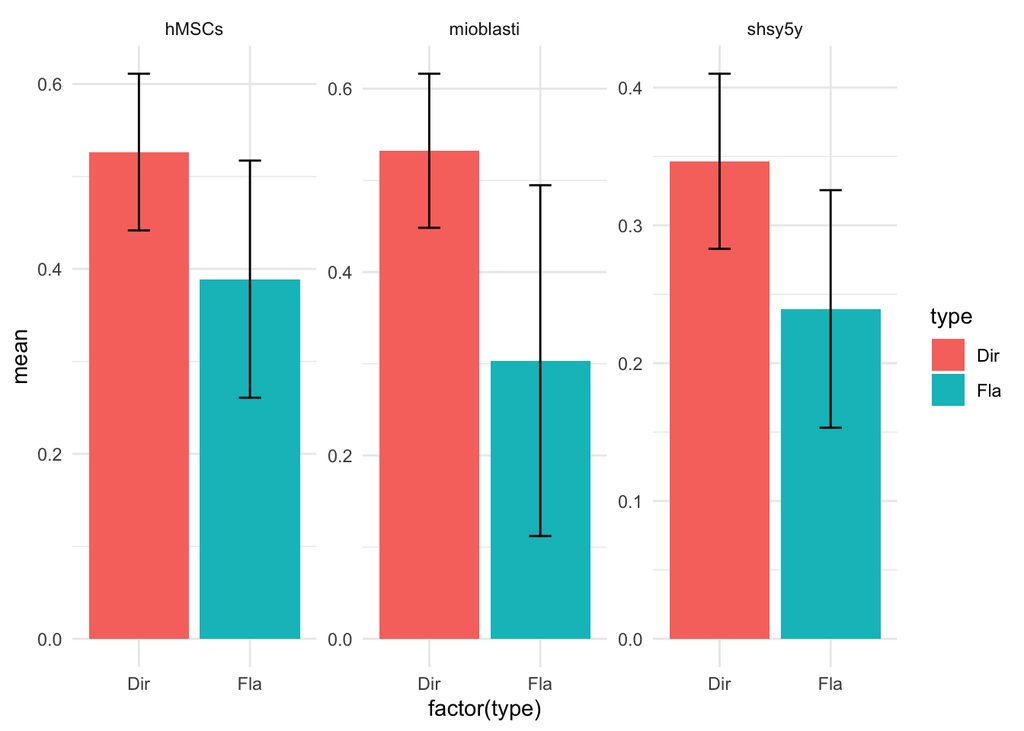

The differences are visible, but we should still do a statistical analysis

## Statistical Approach

We use Welch’s t-test, which is suitable for comparing the mean of two unpaired samples, with different variance. The null hypothesis **H<sub>0</sub>** is that the mean main mass of the chanelled (Dir) surfaces is **smaller** than that of flat surfaces.

```
##        cell             p-value
## 1     hMSCs 0.00357752733107851
## 2 mioblasti 0.00568284130044572
## 3    shsy5y 0.00597024138889315
```

## Combined visualizations

Now we see visually how these angular differences show in the different cells and membrane types.

The first version is with the raw data (very fine-grained with the angles)

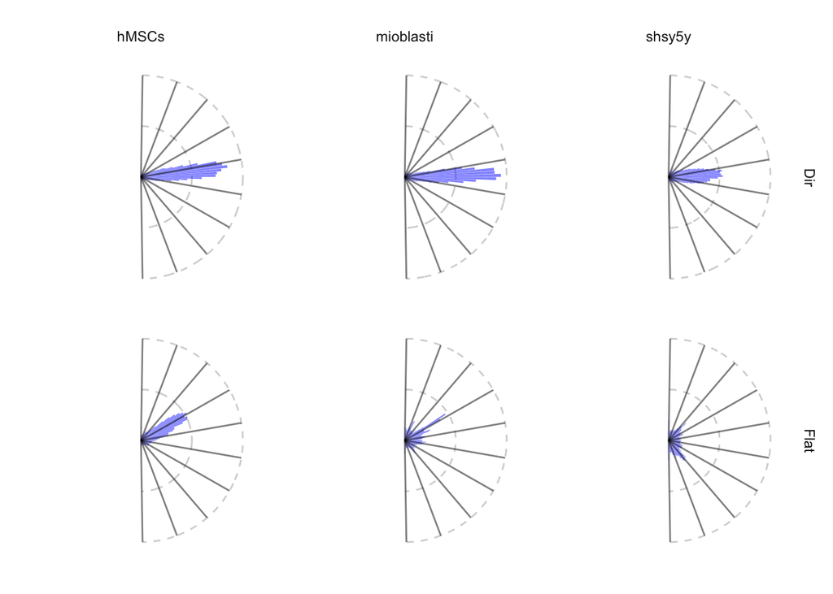

The second version is with the data accumulated in blocks of 20 degrees. If needed, can be made with smaller blocks

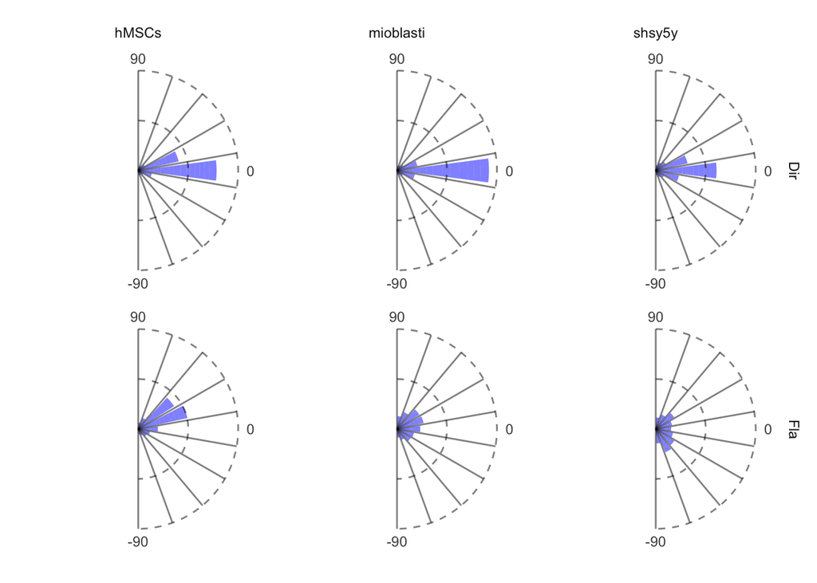